# Solutions to Chapter 3 Exercises

Howard Baek

Last compiled on September 08, 2021

### 3.1.1 Exercises

1. What geoms would you use to draw each of the following named plots?
- Scatterplot: `geom_point()`
- Line chart: `geom_line()`
- Histogram: `geom_histogram()`
- Bar chart: `geom_bar()`
- Pie chart: ggplot2 does not have a geom to draw pie charts. One workaround, according to the [R Graph Gallery](https://www.r-graph-gallery.com/piechart-ggplot2.html) is to build a stacked bar chart with one bar only using the `geom_bar()` function and then make it circular with `coord_polar()`
2. What’s the difference between `geom_path()` and `geom_polygon()`?
- `geom_polygon` draws the same graph (lines) as `geom_path`, but it fills these lines with color. See below:

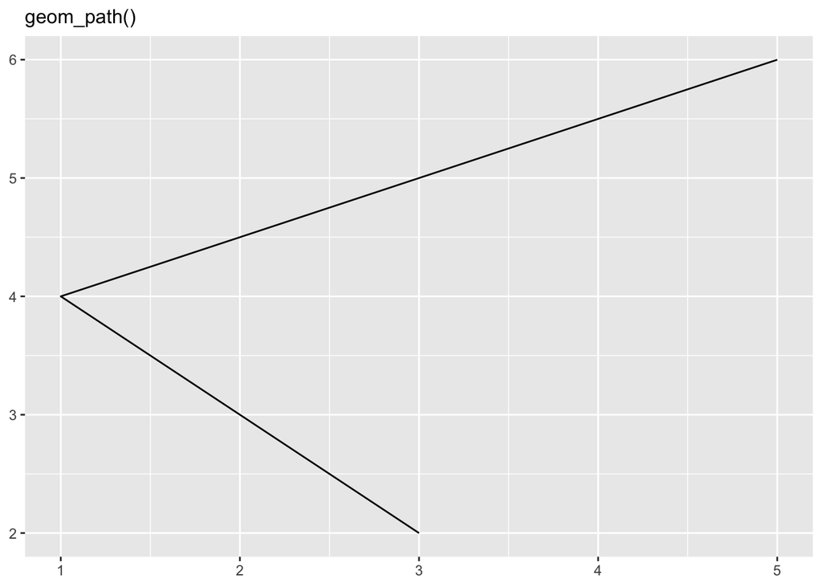

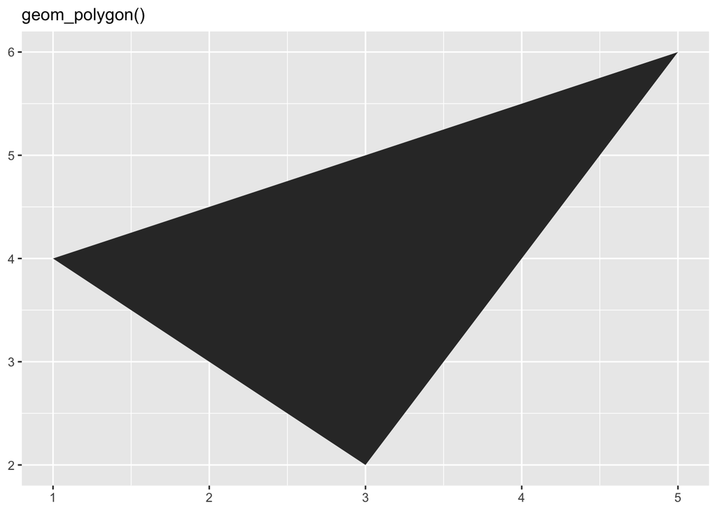

3. What’s the difference between `geom_path()` and `geom_line()`

`geom_line()` connects points from left to right, whereas `geom_path()` connects points in the order they appear in the data. See below:

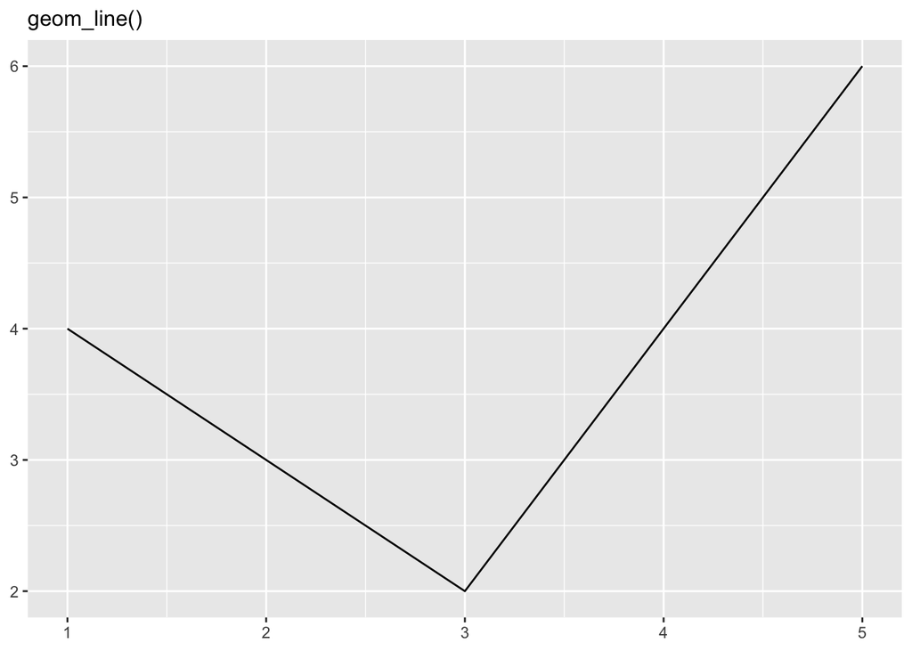

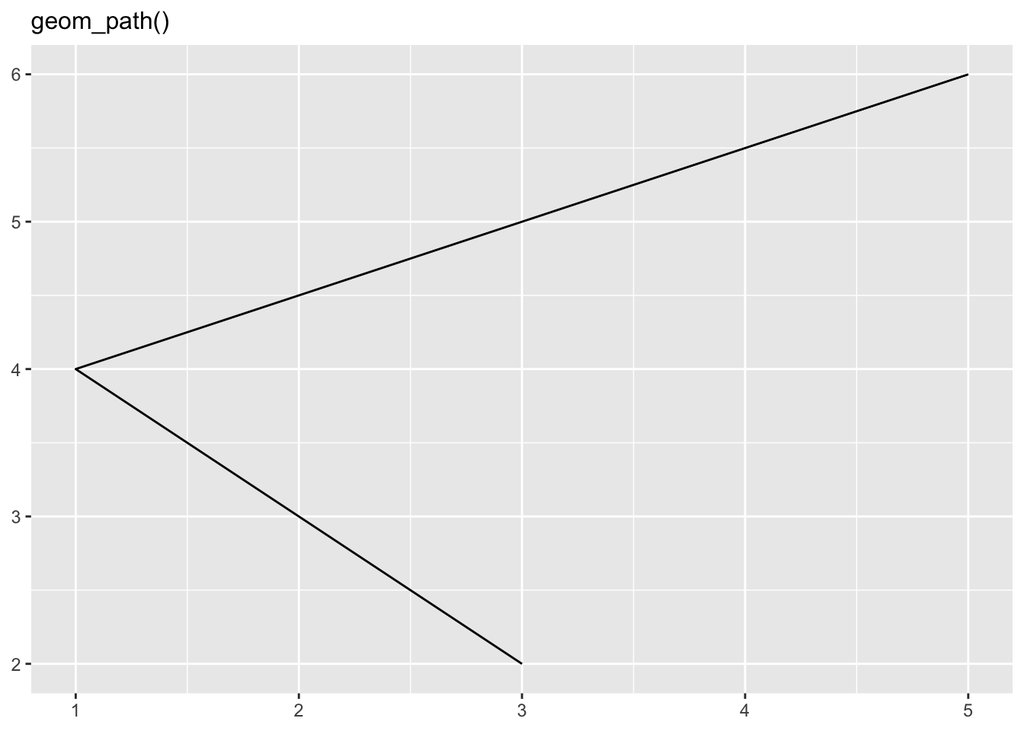

4. What low-level geoms are used to draw `geom_smooth()`? What about `geom_boxplot()` and `geom_violin()`?

(kangnade)

- `geom_point()`, `geom_path()`, and `geom_area()` are used to draw `geom_smooth()`.
- `geom_rect()`, `geom_line()`, `geom_point()` are used for `geom_boxplot()`.
- `geom_area()` and `geom_path()` are used for `geom_violin()`